# Homework 4

Tanner Markham

*Note that you do not need to properly format the axis limits in your plots for this assignment (to save time). You should, however, still make the plots square in shape.*

## Data and Description

Measuring body fat is not simple. One method requires submerging the body underwater in a tank and measuring the increase in water level. A simpler method for estimating body fat would be preferred. In order to develop such a method, researchers recorded age (years), weight (pounds), height (inches), and three body circumference measurements (around the neck, chest, and abdominal (all in centimeters)) for 252 men. Each man’s percentage of body fat was accurately estimated by an underwater weighing technique (the variable brozek is the percentage of body fat). The hope is to be able to use this data to create a model that will accurately predict body fat percentage, by using just the basic variables recorded, without having to use the tank submerging method.

The data can be found in the BodyFat data set on Canvas. Download “BodyFat.txt”, and put it in the same folder as this R Markdown file.

#### 0. Replace the text “< PUT YOUR NAME HERE >” (above next to “author:”) with your full name.

#### 1. Read in the data set, and call the data frame “bodyfat”. Print a summary of the data and make sure the data makes sense. **Remove the “row” column (which contains row numbers) from the data set.**

```r
# Reading data
bodyfat <- read_table("BodyFat.txt")
bodyfat <- bodyfat %>%
  select(!row)

summary(bodyfat)
```

```
##      brozek           age            weight          height
##  Min.   : 0.00   Min.   :22.00   Min.   :118.5   Min.   :64.00
##  1st Qu.:12.80   1st Qu.:35.50   1st Qu.:158.8   1st Qu.:68.38
##  Median :19.00   Median :43.00   Median :176.2   Median :70.00
##  Mean   :18.89   Mean   :44.86   Mean   :178.8   Mean   :70.32
##  3rd Qu.:24.55   3rd Qu.:54.00   3rd Qu.:196.9   3rd Qu.:72.25
##  Max.   :45.10   Max.   :81.00   Max.   :363.1   Max.   :77.75
##       neck           chest           abdom
##  Min.   :31.10   Min.   : 79.3   Min.   : 69.40
##  1st Qu.:36.40   1st Qu.: 94.3   1st Qu.: 84.55
##  Median :38.00   Median : 99.6   Median : 90.90
##  Mean   :37.98   Mean   :100.8   Mean   : 92.49
##  3rd Qu.:39.40   3rd Qu.:105.3   3rd Qu.: 99.20
##  Max.   :51.20   Max.   :136.2   Max.   :148.10
```

#### 2. Create and print a scatterplot matrix of the data.

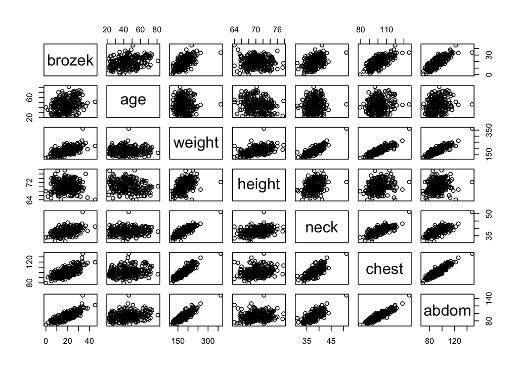

```r
# Scatterplot matrix
pairs(bodyfat)
```

#### 3. Based on the scatterplot matrix, briefly explain which variables you think will be “significant” for predicting brozek and which variables you think will *not* be helpful at predicting brozek. Explain how the scatterplot helped determine your answers.

I think that based on the scatterplot matrix, helpful variables for predictions brozek are weight, neck, chest, and abdom. I think that variables that will not be helpful are age and height. I made these assumptions based on the shape of the scatterplots between brozek and each individual variable. The helpful ones have more of a linear trend, while the unhelpful ones don’t have any shape.

#### 4. Create and print a correlation matrix (numeric or color- and shape-coded).

```r
# Correlation matrix
bodyfat %>%
  cor() %>%
  round(digits = 2)
```

```
##        brozek   age weight height neck chest abdom
## brozek   1.00  0.29   0.61  -0.02 0.49  0.70  0.81
## age      0.29  1.00  -0.01  -0.24 0.11  0.17  0.23
## weight   0.61 -0.01   1.00   0.49 0.83  0.89  0.89
## height  -0.02 -0.24   0.49   1.00 0.33  0.24  0.20
## neck     0.49  0.11   0.83   0.33 1.00  0.78  0.75
## chest    0.70  0.17   0.89   0.24 0.78  1.00  0.92
## abdom    0.81  0.23   0.89   0.20 0.75  0.92  1.00
```

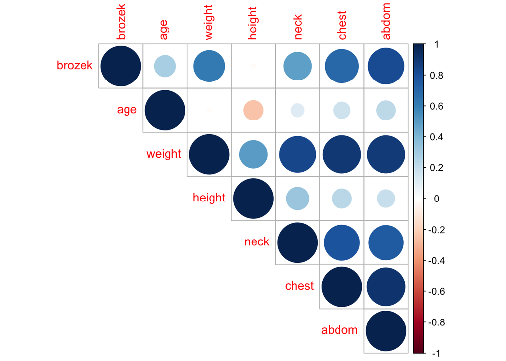

```r
# Plotting correlation
corrplot(cor(bodyfat), type = 'upper')
```

#### 5. Based on the scatterplot matrix and the correlation matrix, are their any pairs of variables that you suspect will cause a problem for the multicollinearity assumption? If so, which ones?

I think that there will be some variables that have problems with the multicollinearity assumption. Chest and abdom are very highly correlated, and weight and both chest and abdom are also pretty correlated.

#### 6. Fit a multiple linear regression model to the data (no transformations). Print a summary of the results. Save the residuals to the `bodyfat` data frame.

```r
# Fitting linear model
bodyfat_lm <- lm(brozek ~., data = bodyfat)
summary(bodyfat_lm)
```

```
##
## Call:
## lm(formula = brozek ~ ., data = bodyfat)
##
## Residuals:
##      Min       1Q   Median       3Q      Max
## -11.5811  -3.0358   0.0668   2.8879  10.2828
##
## Coefficients:
##               Estimate Std. Error t value Pr(>|t|)
## (Intercept) -2.010e+01  1.413e+01  -1.423   0.1561
## age          5.010e-03  2.540e-02   0.197   0.8438
## weight      -8.733e-02  3.879e-02  -2.251   0.0253 *
## height      -1.400e-01  1.520e-01  -0.921   0.3579
## neck        -4.421e-01  2.019e-01  -2.189   0.0295 *
## chest        4.844e-04  9.107e-02   0.005   0.9958
## abdom        8.754e-01  7.924e-02  11.048   <2e-16 ***
## ---
## Signif. codes:  0 '***' 0.001 '**' 0.01 '*' 0.05 '.' 0.1 ' ' 1
##
## Residual standard error: 4.124 on 244 degrees of freedom
## Multiple R-squared:  0.722,  Adjusted R-squared:  0.7151
## F-statistic: 105.6 on 6 and 244 DF,  p-value: < 2.2e-16
```

```r
bodyfat$residuals = bodyfat_lm$residuals
bodyfat$fitted = bodyfat_lm$fitted.values
```

#### 7. Briefly comment on the “significance” of the variables: were you surprised by the results? Are there any variables that are significant that you think shouldn’t be? Are there any variables that are not significant that you think should be?

According to the results of the full model, the significant variables at alpha of .05 are weight, neck, and abdom. I’m not surprised at any of these variables being significant because it makes sense that any of them would be good indicators of body fat percentage. One variable that stood out to be as not being significant was age, because I feel like people tend to have more fat on their bodies at different times in their lives.

#### 8. Briefly comment on the sign (+/-) of the coefficients for the variables. Are their any variables where the sign is the opposite of what you expected?

A lot of this model makes sense to be, but there were a few signs that I didn’t expect. I expected that as weight increases, so would body fat percentage. Same for height and neck measurements but they both have negative signs.

#### 9. Mathematically write out the *fitted* multiple linear regression model for this data set using the coefficients you found above (do not use betas). Do not use “X” and “Y” in your model - use variable names that are fairly descriptive.

$\hat{Brozek_i} = -20.101$ $+$ $0.005Age_i$ $-$ $0.087Weight_i$ $-$ $0.14Height_i$ $-$ $0.442Neck_i$ $+$ $0.00049Chest_i$ $+$ $0.875Abdom_i$

#### 10. *Assuming* the model assumptions are all met, how would you interpret the coefficient for Weight?

Holding all else constant, as weight increases by one pound, brozek decreases in body fat percentage by 0.087 percentage points on average.

#### 11. Briefly explain what it means to “hold all else constant” when interpreting a coefficient.

Holding all else constant means that if you group everything by all predictors except one, those groups will be the same except for the variation caused by that single predictor that you are changing.

#### 12. Briefly explain what the F-test indicates, as reported in the model output from question 6.

The F-test is a hypothesis test that tests for a significant relationship between predictors and responses. If the F-test returns a significant result, it means that there is at least one predictor with a significant linear relationship with the response.

#### 13. Briefly interpret the *adjusted* R-squared, as reported in the model output from question 6.

The adjusted R squared represents the proportion of variation in brozek that can be attributed to all of the predictors in the model, adjusted for the total amount of predictors. In this case, about 72% of the brozek variation is captured by this model adjusting for the six predictors.

### Questions 14-20 involve using diagnostics to determine if the linear regression assumptions are met. For each assumption, (1) perform appropriate diagnostics to determine if the assumption is violated, and (2) explain whether or not you think the assumption is violated and why you think that.

#### 14. (L) The X’s vs Y are linear (use the residual vs. predictor plots, partial regression plots, and one other diagnostic tool of your choice).

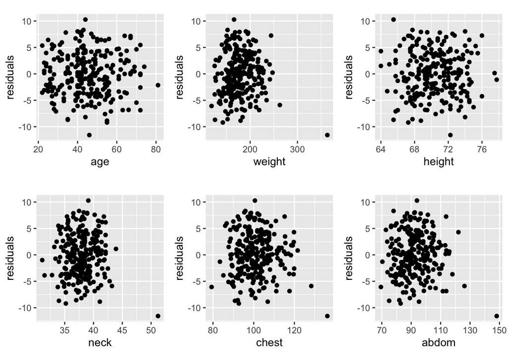

```r
# Residual vs. predictor plots

a = ggplot(data = bodyfat) +
  geom_point(mapping = aes(x = age, y = residuals)) +
  theme(aspect.ratio = 1)

b = ggplot(data = bodyfat) +
  geom_point(mapping = aes(x = weight, y = residuals)) +
  theme(aspect.ratio = 1)

c = ggplot(data = bodyfat) +
  geom_point(mapping = aes(x = height, y = residuals)) +
  theme(aspect.ratio = 1)

d = ggplot(data = bodyfat) +
  geom_point(mapping = aes(x = neck, y = residuals)) +
  theme(aspect.ratio = 1)

e = ggplot(data = bodyfat) +
  geom_point(mapping = aes(x = chest, y = residuals)) +
  theme(aspect.ratio = 1)

f = ggplot(data = bodyfat) +
  geom_point(mapping = aes(x = abdom, y = residuals)) +
  theme(aspect.ratio = 1)

ggarrange(a,b,c,d,e,f,nrow = 2, ncol = 3)
```

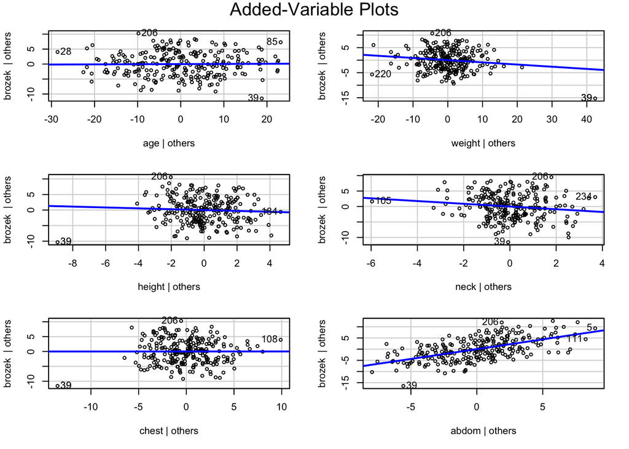

```r
# Partial regression plots
avPlots(bodyfat_lm)
```

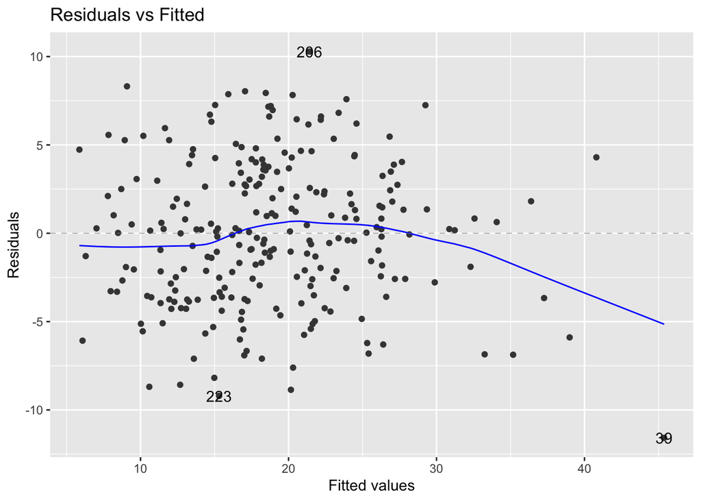

```r
# Residual Vs Fitted
res_vs_fitted <- autoplot(bodyfat_lm, which = 1, ncol = 1, nrow = 1)
res_vs_fitted
```

#### 15. (I) The residuals are independent (no diagnostic tools - just think about how the data was collected and briefly write your thoughts)

There is an argument that the residuals are not independent, because we don’t know if the men in this data set were randomly sampled.

#### 16. (N) The residuals are normally distributed and centered at zero (use all four diagnostic tools)

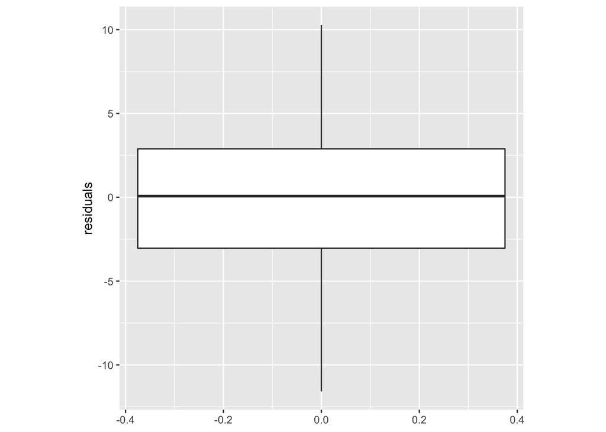

```r
# Boxplot
bodyfat_box <- ggplot(data = bodyfat) +
  geom_boxplot(aes(y = residuals)) +
  theme(aspect.ratio = 1)

bodyfat_box
```

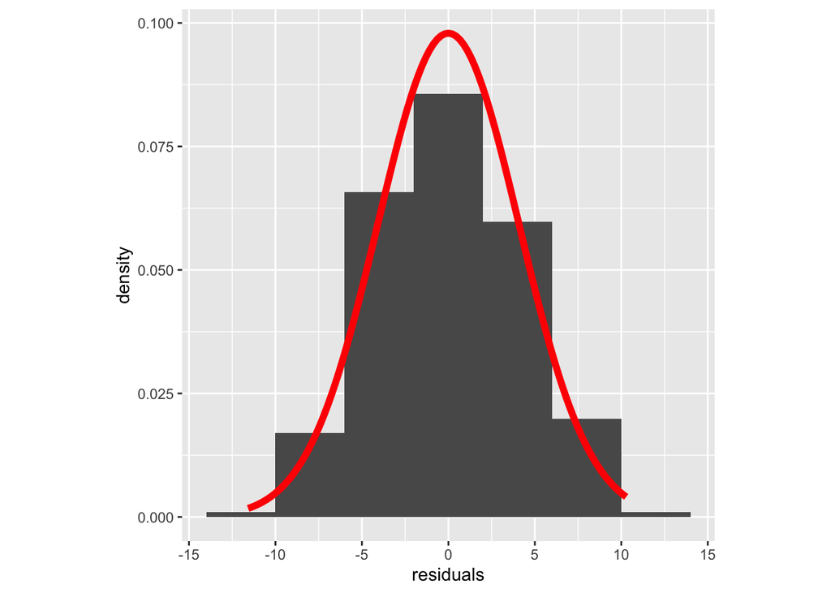

```r
# Histogram
bodyfat_hist <- ggplot(data = bodyfat) +
  geom_histogram(aes(x = residuals, y = ..density..),
                 binwidth = 4) +
  stat_function(fun = dnorm,
                color = 'red',
                size = 2,
                args = list(mean = mean(bodyfat$residuals),
                            sd = sd(bodyfat$residuals))) +
  theme(aspect.ratio = 1)

bodyfat_hist
```

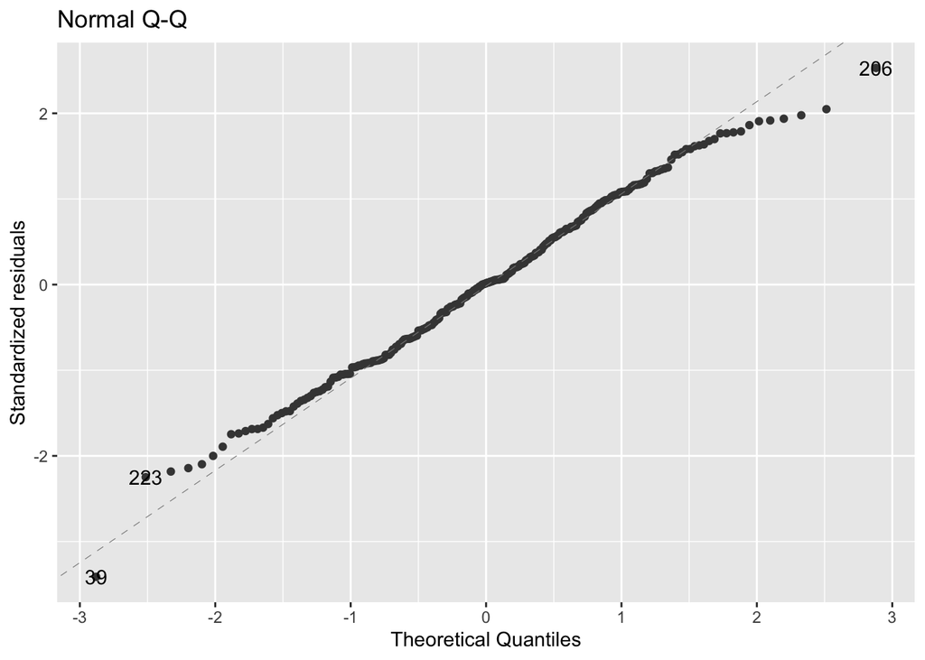

```r
# Normal probability
q_q <- autoplot(bodyfat_lm, which = 2, nrow = 1, ncol = 1)

q_q
```

```r
# Shapiro Wilk
shapiro.test(bodyfat$residuals)
```

```
##
##  Shapiro-Wilk normality test
##
## data:  bodyfat$residuals
## W = 0.99416, p-value = 0.4432
```

Based on the diagnostic tests, I feel comfortable saying that the residuals are normally distributed. Visually, all the plots indicate normality. The shapiro test also returns an insignificant p-value, indicating that there is not enough evidence to reject the null hypothesis stating that the data is normally distributed.

#### 17. (E) The residuals have equal/constant variance across all values of X (only one diagnostic tool)

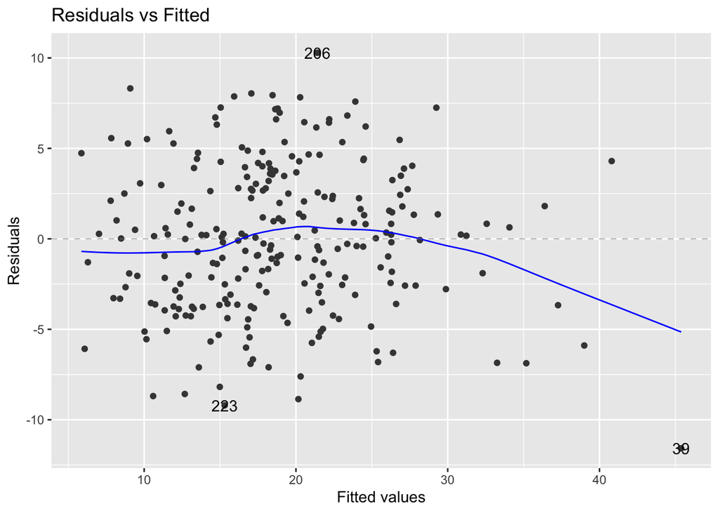

```r
# Residual Vs Fitted
res_vs_fitted
```

I don’t believe that the equal/constant variance assumption is met. I think that the vertical distance between points shrinks at higher fitted values.

#### 18. (A) The model describes all observations (i.e., there are no influential points) (use Cook’s distance, DFBETAS, and DFFITS. Also, in your response, refer to the evidence from the plots you created in previous questions)

```r
# Cook's Distance
bodyfat$cooksd <- cooks.distance(bodyfat_lm)

cook <- ggplot(data = bodyfat) +
  geom_point(mapping = aes(x = as.numeric(rownames(bodyfat)),
                           y = cooksd)) +
  ylab("Cook's Distance") +
  xlab("Observation Number") +
  geom_hline(mapping = aes(yintercept = 4 / length(cooksd)),
             color = "red",
             linetype = "dashed") +
  theme(aspect.ratio = 1)

bodyfat %>%
  mutate(rowNum = row.names(bodyfat)) %>%  # save original row numbers
  filter(cooksd > 4 / length(cooksd)) %>%  # select potential outliers
  arrange(desc(cooksd))
```

```
## # A tibble: 10 × 11
##    brozek   age weight height  neck chest abdom residuals fitted cooksd rowNum
##     <dbl> <dbl>  <dbl>  <dbl> <dbl> <dbl> <dbl>     <dbl>  <dbl>  <dbl> <chr>
##  1   33.8    46   363.   72.2  51.2 136.  148.     -11.6   45.4  0.793  39
##  2   12.7    54   153.   70.5  38.5  99    91.8     -7.61  20.3  0.0272 220
##  3   31.7    44   166    65.5  39.1 101.   93.9     10.3   21.4  0.0268 206
##  4    1.9    35   126.   65.5  34    90.8  75       -8.69  10.6  0.0222 171
##  5   28.3    72   187.   66    38.9 111.  112.      -6.88  35.2  0.0218 249
##  6   11.3    55   180.   68.8  41.1 107.   95.3     -8.86  20.2  0.0218 224
##  7   33.1    45   263.   68.8  43.2 128.  126.      -5.89  39.0  0.0212 40
##  8   17.4    43   152.   67.8  37.5  95.9  78        8.32   9.08 0.0191 127
##  9   25.1    40   191    74    38.3  95.4  92.4      8.04  17.1  0.0164 118
## 10   36.5    42   244.   76    41.8 115.  114.       7.25  29.3  0.0162 191
```

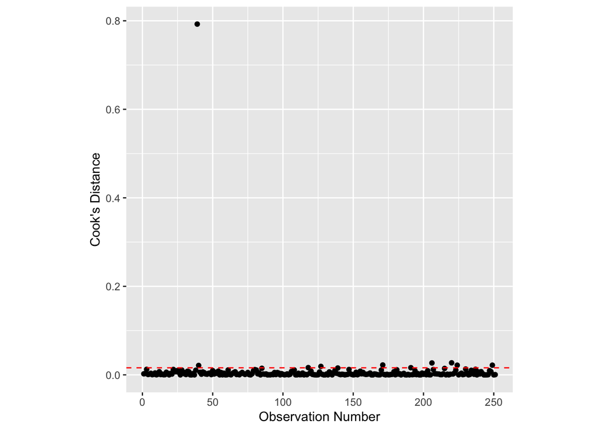

```r
cook
```

```r
# DFBETAS

# Age
bodyfat$dfbetas_age <- as.vector(dfbetas(bodyfat_lm)[, 2])

dfbeta_age <- ggplot(data = bodyfat) +
  geom_point(mapping = aes(x = as.numeric(rownames(bodyfat)),
                           y = abs(dfbetas_age))) +
  ylab("Absolute Value of DFBETAS for Age") +
  xlab("Observation Number") +
  geom_hline(mapping = aes(yintercept = 2 / sqrt(length(dfbetas_age))),
             color = "red",
             linetype = "dashed") +
  theme(aspect.ratio = 1)

# Table view of observations detected by DFBETA
bodyfat %>%
  mutate(rowNum = row.names(bodyfat)) %>%  # save original row numbers
  filter(abs(dfbetas_age) > 2 /
           sqrt(length(rownames(bodyfat)))) %>%  # select potential influential pts
  arrange(desc(abs(dfbetas_age)))
```

```
## # A tibble: 12 × 12
##    brozek   age weight height  neck chest abdom residuals fitted  cooksd dfbet…¹
##     <dbl> <dbl>  <dbl>  <dbl> <dbl> <dbl> <dbl>     <dbl>  <dbl>   <dbl>   <dbl>
##  1   33.8    46   363.   72.2  51.2 136.  148.     -11.6    45.4 0.793    -0.491
##  2   25.8    67   167    67.5  36.5  98.9  89.7      7.16   18.6 0.0148    0.257
##  3   28.6    25   206.   69.8  40.9 111.  100.       6.42   22.2 0.0121   -0.204
##  4   22.4    31   148    67.5  38.8  97.4  88.7      4.18   18.2 0.0108   -0.191
##  5   15.3    28   200.   69.8  41.3 111.   98.8     -5.75   21.1 0.0122    0.185
##  6   24.6    22   154    66.2  34    95.8  87.9      5.35   19.2 0.0124   -0.183
##  7   11.5    70   134.   67    34.9  89.2  83.6     -5.44   16.9 0.00939  -0.160
##  8    6.5    29   160.   71.2  37.3  93.5  84.5     -7.10   13.6 0.00796   0.157
##  9   31.7    44   166    65.5  39.1 101.   93.9     10.3    21.4 0.0268   -0.157
## 10   32.3    72   201    69.8  40.9 108.  105        5.47   26.8 0.00725   0.152
## 11   18.3    61   148.   67.5  36    91.6  81.8      4.75   13.5 0.00535   0.137
## 12   28.8    56   179.   68.5  35.6 103.   94.7      6.61   22.2 0.0110    0.130
## # … with 1 more variable: rowNum <chr>, and abbreviated variable name
## #   ¹dfbetas_age
```

```r
# Weight
bodyfat$dfbetas_weight <- as.vector(dfbetas(bodyfat_lm)[, 3])

dfbeta_weight <- ggplot(data = bodyfat) +
  geom_point(mapping = aes(x = as.numeric(rownames(bodyfat)),
                           y = abs(dfbetas_weight))) +
  ylab("Absolute Value of DFBETAS for Weight") +
  xlab("Observation Number") +
  geom_hline(mapping = aes(yintercept = 2 / sqrt(length(dfbetas_weight))),
             color = "red",
             linetype = "dashed") +
  theme(aspect.ratio = 1)

# Table view of observations detected by DFBETA
bodyfat %>%
  mutate(rowNum = row.names(bodyfat)) %>%  # save original row numbers
  filter(abs(dfbetas_weight) > 2 /
           sqrt(length(rownames(bodyfat)))) %>%  # select potential influential pts
  arrange(desc(abs(dfbetas_weight)))
```

```
## # A tibble: 11 × 13
##    brozek   age weight height  neck chest abdom residu…¹ fitted  cooksd dfbeta…²
##     <dbl> <dbl>  <dbl>  <dbl> <dbl> <dbl> <dbl>    <dbl>  <dbl>   <dbl>    <dbl>
##  1   33.8    46   363.   72.2  51.2 136.  148.    -11.6   45.4  0.793   -0.491
##  2   12.7    54   153.   70.5  38.5  99    91.8    -7.61  20.3  0.0272   0.104
##  3   22.4    31   148    67.5  38.8  97.4  88.7     4.18  18.2  0.0108  -0.191
##  4   25.8    67   167    67.5  36.5  98.9  89.7     7.16  18.6  0.0148   0.257
##  5   11.3    55   180.   68.8  41.1 107.   95.3    -8.86  20.2  0.0218   0.00692
##  6   14.2    28   151.   67.8  34.5  90.2  76.3     5.27   8.93 0.00973 -0.0142
##  7   28.3    72   187.   66    38.9 111.  112.     -6.88  35.2  0.0218  -0.0489
##  8   18.2    52   203.   74.2  42   110   102.     -4.24  22.4  0.00671  0.0165
##  9   28.8    56   179.   68.5  35.6 103.   94.7     6.61  22.2  0.0110   0.130
## 10   25.5    60   158.   67.5  40.4  97.2  93.3     4.66  20.8  0.0102  -0.00780
## 11   31.5    47   195    72.5  40.2 103.  101.      7.59  23.9  0.0120  -0.0495
## # … with 2 more variables: dfbetas_weight <dbl>, rowNum <chr>, and abbreviated
## #   variable names ¹residuals, ²dfbetas_age
```

```r
# Height
bodyfat$dfbetas_height <- as.vector(dfbetas(bodyfat_lm)[, 4])

dfbeta_height <- ggplot(data = bodyfat) +
  geom_point(mapping = aes(x = as.numeric(rownames(bodyfat)),
                           y = abs(dfbetas_height))) +
  ylab("Absolute Value of DFBETAS for Height") +
  xlab("Observation Number") +
  geom_hline(mapping = aes(yintercept = 2 / sqrt(length(dfbetas_height))),
             color = "red",
             linetype = "dashed") +
  theme(aspect.ratio = 1)

# Table view of observations detected by DFBETA
bodyfat %>%
  mutate(rowNum = row.names(bodyfat)) %>%  # save original row numbers
  filter(abs(dfbetas_height) > 2 /
           sqrt(length(rownames(bodyfat)))) %>%  # select potential influential pts
  arrange(desc(abs(dfbetas_height)))
```

```
## # A tibble: 19 × 14
##    brozek   age weight height  neck chest abdom residu…¹ fitted  cooksd dfbeta…²
##     <dbl> <dbl>  <dbl>  <dbl> <dbl> <dbl> <dbl>    <dbl>  <dbl>   <dbl>    <dbl>
##  1   33.8    46   363.   72.2  51.2 136.  148.    -11.6   45.4  0.793   -0.491
##  2   12.7    54   153.   70.5  38.5  99    91.8    -7.61  20.3  0.0272   0.104
##  3   31.7    44   166    65.5  39.1 101.   93.9    10.3   21.4  0.0268  -0.157
##  4   20.1    49   213.   75    40.8 105.  107.     -6.30  26.4  0.0154   0.00427
##  5   14.2    28   151.   67.8  34.5  90.2  76.3     5.27   8.93 0.00973 -0.0142
##  6   25.8    67   167    67.5  36.5  98.9  89.7     7.16  18.6  0.0148   0.257
##  7   17.4    43   152.   67.8  37.5  95.9  78       8.32   9.08 0.0191   0.0417
##  8   33.1    45   263.   68.8  43.2 128.  126.     -5.89  39.0  0.0212   0.0545
##  9   36.5    42   244.   76    41.8 115.  114.      7.25  29.3  0.0162  -0.0256
## 10   18.2    52   203.   74.2  42   110   102.     -4.24  22.4  0.00671  0.0165
## 11   19.1    43   200.   73.5  38.6 105.  103.     -6.22  25.3  0.00762  0.0556
## 12   28.4    43   188.   74    37.7  97.8  98.6     5.35  23.1  0.0100  -0.0341
## 13    6.8    44   184    74    37.9 101.   89.1    -8.18  15.0  0.00926 -0.0536
## 14   31.5    47   195    72.5  40.2 103.  101.      7.59  23.9  0.0120  -0.0495
## 15    1.9    35   126.   65.5  34    90.8  75      -8.69  10.6  0.0222   0.125
## 16   28.8    65   190.   65.8  40.8 106.  100.      4.36  24.4  0.00662  0.0912
## 17    4.1    35   152.   67.8  37    92.2  81.9    -8.58  12.7  0.0108   0.0886
## 18   17.2    28   172.   75.2  35.6  92.1  83.5     5.27  11.9  0.00816 -0.0456
## 19   27.5    50   197.   68.2  42.1 106.   98.8     6.16  21.3  0.0104   0.0175
## # … with 3 more variables: dfbetas_weight <dbl>, dfbetas_height <dbl>,
## #   rowNum <chr>, and abbreviated variable names ¹residuals, ²dfbetas_age
```

```r
# Neck
bodyfat$dfbetas_neck <- as.vector(dfbetas(bodyfat_lm)[, 5])

dfbeta_neck <- ggplot(data = bodyfat) +
  geom_point(mapping = aes(x = as.numeric(rownames(bodyfat)),
                           y = abs(dfbetas_neck))) +
  ylab("Absolute Value of DFBETAS for Neck") +
  xlab("Observation Number") +
  geom_hline(mapping = aes(yintercept = 2 / sqrt(length(dfbetas_neck))),
             color = "red",
             linetype = "dashed") +
  theme(aspect.ratio = 1)

# Table view of observations detected by DFBETA
bodyfat %>%
  mutate(rowNum = row.names(bodyfat)) %>%  # save original row numbers
  filter(abs(dfbetas_neck) > 2 /
           sqrt(length(rownames(bodyfat)))) %>%  # select potential influential pts
  arrange(desc(abs(dfbetas_neck)))
```

```
## # A tibble: 18 × 15
##    brozek   age weight height  neck chest abdom residu…¹ fitted  cooksd dfbeta…²
##     <dbl> <dbl>  <dbl>  <dbl> <dbl> <dbl> <dbl>    <dbl>  <dbl>   <dbl>    <dbl>
##  1   11.3    55   180.   68.8  41.1 107.   95.3    -8.86   20.2 0.0218   0.00692
##  2   12.7    54   153.   70.5  38.5  99    91.8    -7.61   20.3 0.0272   0.104
##  3   28.8    56   179.   68.5  35.6 103.   94.7     6.61   22.2 0.0110   0.130
##  4   31.7    44   166    65.5  39.1 101.   93.9    10.3    21.4 0.0268  -0.157
##  5   25.5    60   158.   67.5  40.4  97.2  93.3     4.66   20.8 0.0102  -0.00780
##  6   27.5    50   197.   68.2  42.1 106.   98.8     6.16   21.3 0.0104   0.0175
##  7   22.4    31   148    67.5  38.8  97.4  88.7     4.18   18.2 0.0108  -0.191
##  8    4.9    42   136.   67.5  37.8  87.6  77.6    -5.12   10.0 0.00827  0.0351
##  9   31.7    44   205    69.5  36.6 106   104.      4.04   27.7 0.00579  0.0197
## 10   31.5    47   195    72.5  40.2 103.  101.      7.59   23.9 0.0120  -0.0495
## 11   26      64   150.   67.2  38.1  97.1  89       7.20   18.8 0.0110   0.0807
## 12   25.8    67   167    67.5  36.5  98.9  89.7     7.16   18.6 0.0148   0.257
## 13   15.3    28   200.   69.8  41.3 111.   98.8    -5.75   21.1 0.0122   0.185
## 14   33.6    65   224.   68.2  38.8 120.  118      -3.67   37.3 0.00718 -0.0582
## 15   21.8    40   168.   71.2  34.3  98.3  88.5     4.01   17.8 0.00363 -0.00214
## 16    9.4    55   147.   68.8  38.7  88.5  82.8    -3.75   13.2 0.00542 -0.0374
## 17   18.2    52   203.   74.2  42   110   102.     -4.24   22.4 0.00671  0.0165
## 18   28.9    55   184.   67.5  40.9 103   100.      4.43   24.5 0.00506 -0.00350
## # … with 4 more variables: dfbetas_weight <dbl>, dfbetas_height <dbl>,
## #   dfbetas_neck <dbl>, rowNum <chr>, and abbreviated variable names
## #   ¹residuals, ²dfbetas_age
```

```r
# Chest
bodyfat$dfbetas_chest <- as.vector(dfbetas(bodyfat_lm)[, 6])

dfbeta_chest <- ggplot(data = bodyfat) +
  geom_point(mapping = aes(x = as.numeric(rownames(bodyfat)),
                           y = abs(dfbetas_chest))) +
  ylab("Absolute Value of DFBETAS for Chest") +
  xlab("Observation Number") +
  geom_hline(mapping = aes(yintercept = 2 / sqrt(length(dfbetas_chest))),
             color = "red",
             linetype = "dashed") +
  theme(aspect.ratio = 1)

# Table view of observations detected by DFBETA
bodyfat %>%
  mutate(rowNum = row.names(bodyfat)) %>%  # save original row numbers
  filter(abs(dfbetas_chest) > 2 /
           sqrt(length(rownames(bodyfat)))) %>%  # select potential influential pts
  arrange(desc(abs(dfbetas_chest)))
```

```
## # A tibble: 14 × 16
##    brozek   age weight height  neck chest abdom residu…¹ fitted  cooksd dfbeta…²
##     <dbl> <dbl>  <dbl>  <dbl> <dbl> <dbl> <dbl>    <dbl>  <dbl>   <dbl>    <dbl>
##  1   33.8    46   363.   72.2  51.2 136.  148.    -11.6   45.4  0.793   -0.491
##  2   25.1    40   191    74    38.3  95.4  92.4     8.04  17.1  0.0164   0.0447
##  3   17.2    43   194    75.5  38.5 110.   88.7     3.92  13.3  0.0111   0.0212
##  4   11.3    55   180.   68.8  41.1 107.   95.3    -8.86  20.2  0.0218   0.00692
##  5   15.3    28   200.   69.8  41.3 111.   98.8    -5.75  21.1  0.0122   0.185
##  6    0      40   118.   68    33.8  79.3  69.4    -6.08   6.08 0.0114  -0.0244
##  7   20.1    49   213.   75    40.8 105.  107.     -6.30  26.4  0.0154   0.00427
##  8   11.1    57   148.   65.8  35.2  99.6  86.4    -7.10  18.2  0.0131  -0.0736
##  9   17.6    32   149.   70    35.5  86.7  80       5.95  11.6  0.00709 -0.0541
## 10    1.9    35   126.   65.5  34    90.8  75      -8.69  10.6  0.0222   0.125
## 11   10.7    47   158.   72.2  34.9  90.2  86.7    -6.01  16.7  0.00956 -0.0416
## 12   20.1    58   182.   68    39.1 100    99.8    -4.85  24.9  0.00520 -0.0457
## 13   28.4    43   188.   74    37.7  97.8  98.6     5.35  23.1  0.0100  -0.0341
## 14   30.2    67   164.   67.8  38.4  97.7  95.8     6.81  23.4  0.0119   0.106
## # … with 5 more variables: dfbetas_weight <dbl>, dfbetas_height <dbl>,
## #   dfbetas_neck <dbl>, dfbetas_chest <dbl>, rowNum <chr>, and abbreviated
## #   variable names ¹residuals, ²dfbetas_age
```

```r
# Abdom
bodyfat$dfbetas_abdom <- as.vector(dfbetas(bodyfat_lm)[, 7])

dfbeta_abdom <- ggplot(data = bodyfat) +
  geom_point(mapping = aes(x = as.numeric(rownames(bodyfat)),
                           y = abs(dfbetas_abdom))) +
  ylab("Absolute Value of DFBETAS for Abdom") +
  xlab("Observation Number") +
  geom_hline(mapping = aes(yintercept = 2 / sqrt(length(dfbetas_abdom))),
             color = "red",
             linetype = "dashed") +
  theme(aspect.ratio = 1)

# Table view of observations detected by DFBETA
bodyfat %>%
  mutate(rowNum = row.names(bodyfat)) %>%  # save original row numbers
  filter(abs(dfbetas_abdom) > 2 /
           sqrt(length(rownames(bodyfat)))) %>%  # select potential influential pts
  arrange(desc(abs(dfbetas_abdom)))
```

```
## # A tibble: 16 × 17
##    brozek   age weight height  neck chest abdom residu…¹ fitted  cooksd dfbeta…²
##     <dbl> <dbl>  <dbl>  <dbl> <dbl> <dbl> <dbl>    <dbl>  <dbl>   <dbl>    <dbl>
##  1   33.8    46   363.   72.2  51.2 136.  148.    -11.6   45.4  0.793   -0.491
##  2   17.4    43   152.   67.8  37.5  95.9  78       8.32   9.08 0.0191   0.0417
##  3   12.7    54   153.   70.5  38.5  99    91.8    -7.61  20.3  0.0272   0.104
##  4   20.1    49   213.   75    40.8 105.  107.     -6.30  26.4  0.0154   0.00427
##  5   31.5    47   195    72.5  40.2 103.  101.      7.59  23.9  0.0120  -0.0495
##  6   28.3    72   187.   66    38.9 111.  112.     -6.88  35.2  0.0218  -0.0489
##  7   28.4    43   188.   74    37.7  97.8  98.6     5.35  23.1  0.0100  -0.0341
##  8   19.1    43   200.   73.5  38.6 105.  103.     -6.22  25.3  0.00762  0.0556
##  9   25.8    67   167    67.5  36.5  98.9  89.7     7.16  18.6  0.0148   0.257
## 10   14.2    28   151.   67.8  34.5  90.2  76.3     5.27   8.93 0.00973 -0.0142
## 11   22.4    31   148    67.5  38.8  97.4  88.7     4.18  18.2  0.0108  -0.191
## 12   17.2    43   194    75.5  38.5 110.   88.7     3.92  13.3  0.0111   0.0212
## 13   30.2    67   164.   67.8  38.4  97.7  95.8     6.81  23.4  0.0119   0.106
## 14   17.9    44   188.   72.2  38   102.   87.5     4.42  13.5  0.00361  0.0650
## 15   45.1    51   219    64    41.2 120.  122.      4.30  40.8  0.0144  -0.0974
## 16    5.1    25   191    74    38.1 101.   82.5    -3.31   8.41 0.00425  0.00783
## # … with 6 more variables: dfbetas_weight <dbl>, dfbetas_height <dbl>,
## #   dfbetas_neck <dbl>, dfbetas_chest <dbl>, dfbetas_abdom <dbl>, rowNum <chr>,
## #   and abbreviated variable names ¹residuals, ²dfbetas_age
```

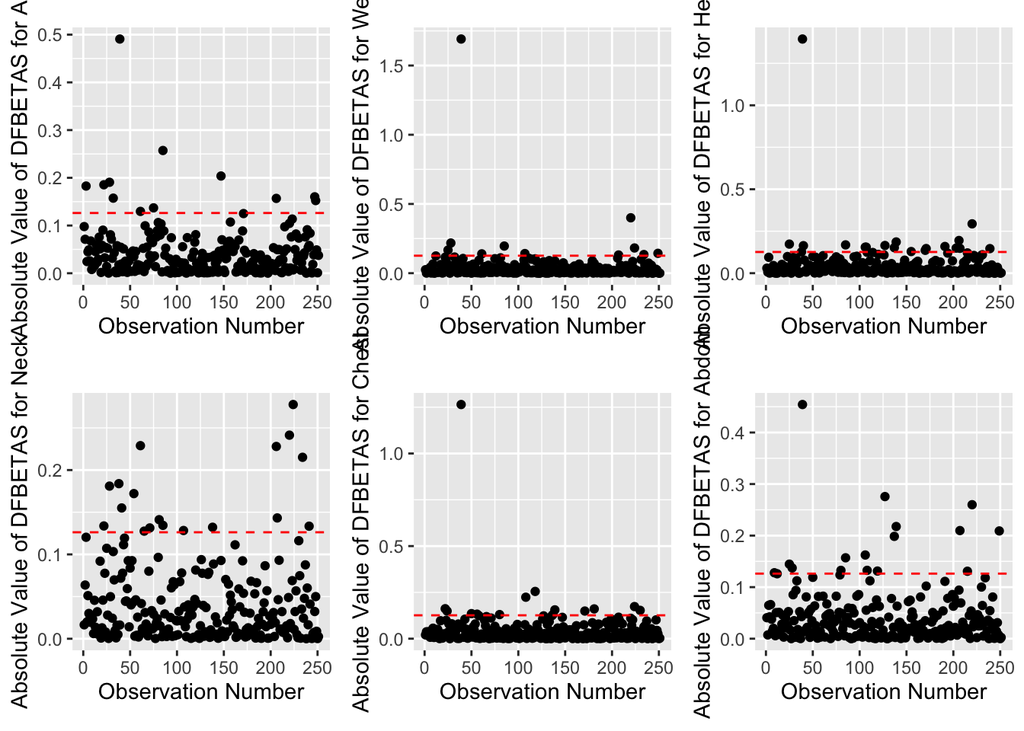

```r
# Table view of plots
ggarrange(dfbeta_age, dfbeta_weight, dfbeta_height, dfbeta_neck, dfbeta_chest, dfbeta_abdom,
          nrow = 2, ncol = 3)
```

```r
# DFFITS
bodyfat$dffits <- dffits(bodyfat_lm)

dffits <- ggplot(data = bodyfat) +
  geom_point(mapping = aes(x = as.numeric(rownames(bodyfat)),
                           y = abs(dffits))) +
  ylab("Absolute Value of DFFITS for Brozek") +
  xlab("Observation Number") +
  geom_hline(mapping = aes(yintercept = 2 * sqrt(length(bodyfat_lm$coefficients) /
                                                   length(dffits))),
             color = "red",
             linetype = "dashed") +
  theme(aspect.ratio = 1)

bodyfat %>%
  mutate(rowNum = row.names(bodyfat)) %>%  # save original row numbers
  # select potential influential pts
  filter(abs(dffits) > 2 * sqrt(length(bodyfat_lm$coefficients) /
                                  length(dffits))) %>%
  arrange(desc(abs(dffits)))
```

```
## # A tibble: 10 × 18
##    brozek   age weight height  neck chest abdom residuals fitted cooksd dfbeta…¹
##     <dbl> <dbl>  <dbl>  <dbl> <dbl> <dbl> <dbl>     <dbl>  <dbl>  <dbl>    <dbl>
##  1   33.8    46   363.   72.2  51.2 136.  148.     -11.6   45.4  0.793  -0.491
##  2   12.7    54   153.   70.5  38.5  99    91.8     -7.61  20.3  0.0272  0.104
##  3   31.7    44   166    65.5  39.1 101.   93.9     10.3   21.4  0.0268 -0.157
##  4    1.9    35   126.   65.5  34    90.8  75       -8.69  10.6  0.0222  0.125
##  5   11.3    55   180.   68.8  41.1 107.   95.3     -8.86  20.2  0.0218  0.00692
##  6   28.3    72   187.   66    38.9 111.  112.      -6.88  35.2  0.0218 -0.0489
##  7   33.1    45   263.   68.8  43.2 128.  126.      -5.89  39.0  0.0212  0.0545
##  8   17.4    43   152.   67.8  37.5  95.9  78        8.32   9.08 0.0191  0.0417
##  9   25.1    40   191    74    38.3  95.4  92.4      8.04  17.1  0.0164  0.0447
## 10   36.5    42   244.   76    41.8 115.  114.       7.25  29.3  0.0162 -0.0256
## # … with 7 more variables: dfbetas_weight <dbl>, dfbetas_height <dbl>,
## #   dfbetas_neck <dbl>, dfbetas_chest <dbl>, dfbetas_abdom <dbl>, dffits <dbl>,
## #   rowNum <chr>, and abbreviated variable name ¹dfbetas_age
```

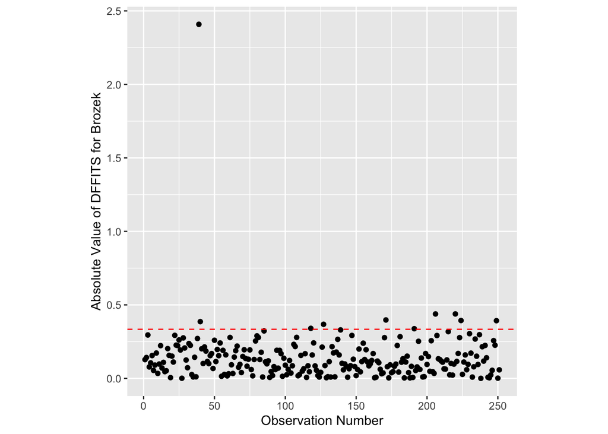

```r
dffits
```

I believe that there is at least one influential point in the data. One observation in particular, the observation at row 39, is particularly glaring. It’s a red flag on nearly every plot between the cooks, dfbeta, and dffits tests.

#### 19. (R) Additional predictor variables are not required (no diagnostic tools - just think about the variables you have and if there are other variables you think would help predict the response)

I think that these variables all do a good job of capturing the outcome variable that we’re looking at, in this case body fat percentage. I do believe that there are some variables found in blood work like cholesterol for example, that could be helpful in improving the model.

#### 20. No multicollinearity (for this assumption, compute the variance inflation factors (VIFs) and compare the VIFs to your comments in questions 5. Do the variance inflation factors match your assumptions from questions 5? Is this assumption met?

```r
#VIF

vif(bodyfat_lm)
```

```
##       age    weight    height      neck     chest     abdom
##  1.510958 19.128777  2.306983  3.545106  8.604128 10.684888
```

```r
mean(vif(bodyfat_lm))
```

```
## [1] 7.63014
```

Based on the variance inflation factors, the multicollinearity assumption is not met. The VIF for weight, chest, and abdom are all very high and the overall average VIF is also too high. This matches my assumption made in question five where I observed that there were correlation issues with weight, chest, and abdom.

### Note: your next homework assigment will use this same data set, and you will be asked to fix the assumptions that were broken.

#### 21. Briefly summarize what you learned, personally, from this analysis about the statistics, model fitting process, etc.

This assignment has taught me that while all linear models that we’ve learned about so far have the same backbone, you really need to pay attention to the type of model that you’re fitting in order to understand what assumptions you need to look for.

#### 22. Briefly summarize what you learned from this analysis *to a non-statistician*. Write a few sentences about (1) the purpose of this data set and analysis and (2) what you learned about this data set from your analysis. Write your response as if you were addressing a business manager (avoid using statistics jargon) and just provide the main take-aways.

Using this data, we would like to analyze the relationship between brozek (body fat percentage) and various body measurements such as age, weight, height, neck, chest, and abdom. While this particular combination of variables can significantly predict brozek, there are some problematic relationships in the data that need to be addressed before any actionable insight can be used.